# 5.3-Genome_analysis_complete

```python
import matplotlib.pyplot as plt
import numpy as np
import pandas as pd
import seaborn as sns
from intro_Data_5 import *
```

## 1. Motivation

Characterization of environmental microbial communities can involve large scale DNA sequencing. One task in the analysis pipeline can be binning sequences or contigs (larger sequences made by putting smaller sequences together) prior to further analysis. This can put sequences from the same organism together in a group so that they can be analyzed separately and can be used to find contaminants (like human DNA!). We may not know what the sequences are, i.e. they have no labels, but we can group them based on patterns of letters they contain. In this example, we look at 4 letter patterns, otherwise known as tetranucleotides.

```python
data = pd.read_csv('data/DNA_data.csv')
```

```python
data.head() # what is the dimension of the data?
```

|  | AAAA | AAAC | AAAT | AAAG | AACA | AACC | AACT | AACG | AATA | AATC | ... | GGCT | GGCG | GGTA | GGTC | GGTT | GGTG | GGGA | GGGC | GGGT | GGGG |
| --- | --- | --- | --- | --- | --- | --- | --- | --- | --- | --- | --- | --- | --- | --- | --- | --- | --- | --- | --- | --- | --- |
| 0 | 0.003590 | 0.003675 | 0.004523 | 0.002541 | 0.005437 | 0.002962 | 0.003883 | 0.004101 | 0.005245 | 0.005914 | ... | 0.002811 | 0.003309 | 0.002535 | 0.003914 | 0.002962 | 0.004354 | 0.002910 | 0.001840 | 0.002707 | 0.001785 |
| 1 | 0.003195 | 0.003714 | 0.003834 | 0.002509 | 0.005379 | 0.003127 | 0.003652 | 0.004227 | 0.004291 | 0.006100 | ... | 0.002825 | 0.003506 | 0.002371 | 0.004111 | 0.003127 | 0.004668 | 0.003233 | 0.001972 | 0.002921 | 0.001995 |
| 2 | 0.003269 | 0.004386 | 0.005131 | 0.002317 | 0.006207 | 0.003393 | 0.003807 | 0.003434 | 0.006910 | 0.007365 | ... | 0.001945 | 0.002441 | 0.002317 | 0.003393 | 0.003393 | 0.004345 | 0.002897 | 0.001200 | 0.002938 | 0.002441 |
| 3 | 0.003142 | 0.004164 | 0.003300 | 0.001964 | 0.006442 | 0.002907 | 0.004085 | 0.004557 | 0.005264 | 0.006285 | ... | 0.002121 | 0.003614 | 0.001493 | 0.004399 | 0.002907 | 0.003849 | 0.002514 | 0.002043 | 0.002593 | 0.002121 |
| 4 | 0.004763 | 0.003297 | 0.006137 | 0.002473 | 0.005404 | 0.003114 | 0.003297 | 0.003252 | 0.007007 | 0.006183 | ... | 0.002473 | 0.002977 | 0.002107 | 0.003114 | 0.003114 | 0.004488 | 0.002244 | 0.002107 | 0.002610 | 0.002244 |

5 rows × 256 columns

```python
from sklearn.preprocessing import StandardScaler as SS
X = SS().fit_transform(data.values)
X[:5,]
```

```
array([[-0.25025671, -0.02105438,  0.00543117, ..., -0.45244946,
        -0.36103047, -0.43115167],
       [-0.31300997, -0.00417599, -0.20408516, ..., -0.43093757,
        -0.26991905, -0.40852686],
       [-0.30133192,  0.29095164,  0.19010173, ..., -0.55657083,
        -0.26265326, -0.36064623],
       [-0.32144882,  0.1933219 , -0.36636496, ..., -0.41942503,
        -0.40989057, -0.39502326],
       [-0.06371466, -0.18690822,  0.49576222, ..., -0.40898695,
        -0.40222468, -0.38182204]])
```

## 2. Unsupervised exploration

### PCA and tSNE

```python
from sklearn.decomposition import PCA
pca = PCA()
pca_props = pca.fit_transform(X)
```

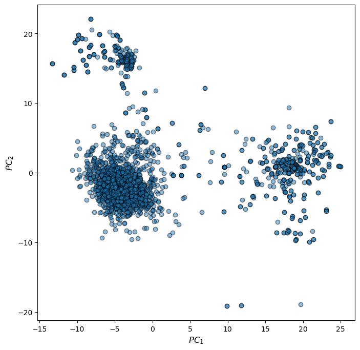

```python
plt.figure(figsize= [8,8])
plt.scatter(pca_props[:,0], pca_props[:,1], alpha = 0.5, ec = 'k')
plt.xlabel('$PC_1$', fontsize = 12)
plt.ylabel('$PC_2$', fontsize = 12)

plt.show()
```

```python
pca.explained_variance_ratio_[:25]
```

```
array([0.32331585, 0.12804683, 0.05403234, 0.02978684, 0.0272901 ,
       0.02565754, 0.02115854, 0.01913828, 0.01638842, 0.01430024,
       0.01374585, 0.01369477, 0.01253893, 0.01193362, 0.01156239,
       0.01066115, 0.00983257, 0.00940089, 0.00897706, 0.00894302,
       0.00806395, 0.00750297, 0.00708545, 0.00695983, 0.00665264])
```

```python
np.cumsum(pca.explained_variance_ratio_[:24])
```

```
array([0.32331585, 0.45136269, 0.50539503, 0.53518187, 0.56247197,
       0.58812951, 0.60928805, 0.62842633, 0.64481475, 0.65911499,
       0.67286085, 0.68655562, 0.69909455, 0.71102817, 0.72259057,
       0.73325171, 0.74308428, 0.75248518, 0.76146223, 0.77040525,
       0.7784692 , 0.78597217, 0.79305762, 0.80001746])
```

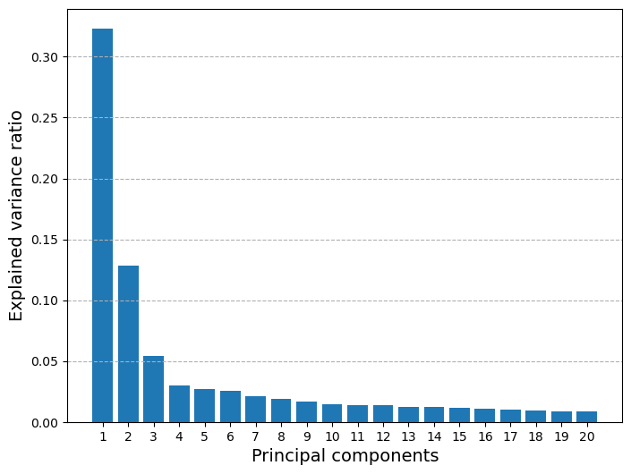

```python
evr = pca.explained_variance_ratio_[:20]

plt.figure(figsize=(8,6))
plt.bar(range(1, len(evr)+1), evr)
plt.xticks(range(1, len(evr)+1))
plt.grid(axis = 'y', linestyle = '--')
plt.xlabel('Principal components', fontsize=14)
plt.ylabel('Explained variance ratio', fontsize=14)
plt.show()
```

We will use these PCs as input to tSNE. Why?

```python
from sklearn.manifold import TSNE
tsne = TSNE(random_state = 146)
tsne_props = tsne.fit_transform(pca_props[:,:24])
```

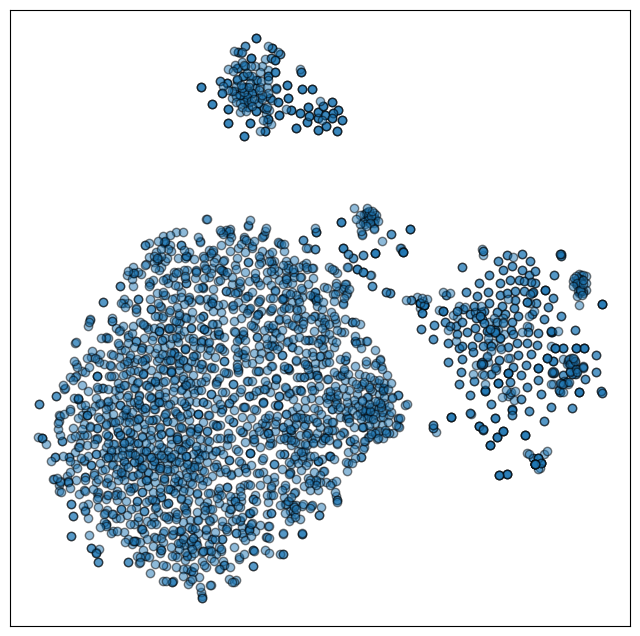

```python
plt.figure(figsize = [8,8])
plt.scatter(tsne_props[:,0], tsne_props[:,1], alpha = 0.5, ec = 'k')
plt.xticks([])
plt.yticks([])
plt.show()
```

**QUESTION**  
How does the tSNE plot differ from the PCA?

### k-means clustering

```python
from sklearn.cluster import KMeans
```

```python
X = pca_props[:,:24]
```

```python
k_range = np.arange(1,11)
scores = []
for k in k_range:
    km = KMeans(n_clusters = k, random_state = 146, n_init=10)
    km.fit(X)
    scores.append(km.score(X))
```

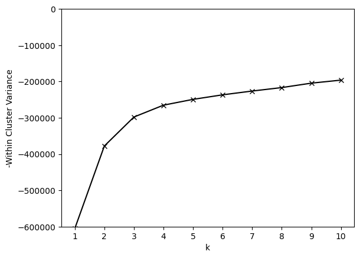

```python
plt.plot(k_range, scores, '-xk')
plt.xlabel('k')
plt.xticks(k_range)
plt.ylabel('-Within Cluster Variance')
plt.ylim(-600000,0)
plt.show()
```

```python
# 1. repeat these N experiments (e.g., by changing random_states ... ) --> K_{i}

# 2. average K

# 3. uncertainty would be std(K)/ sqrt(N_{experiments})
```

**QUESTION**  
Do the results from this plot agree with what you found for PCA/tSNE? Where is the `Elbow' of this curve?

```python
km = KMeans(n_clusters = 3, random_state = 146)
```

```python
groups = km.fit_predict(X)

print(groups)
```

```
[0 0 0 ... 2 2 2]
```

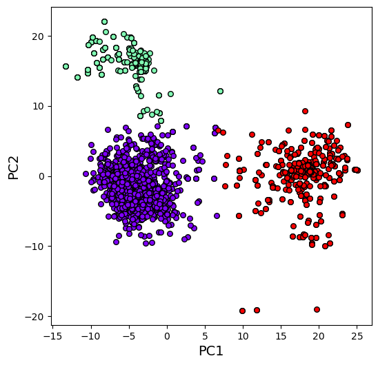

```python
from intro_Data_5 import *

plot_groups(pca_props[:,:2],groups,colors = get_colors(3), labels = ['PC1','PC2'])
plt.show()
```

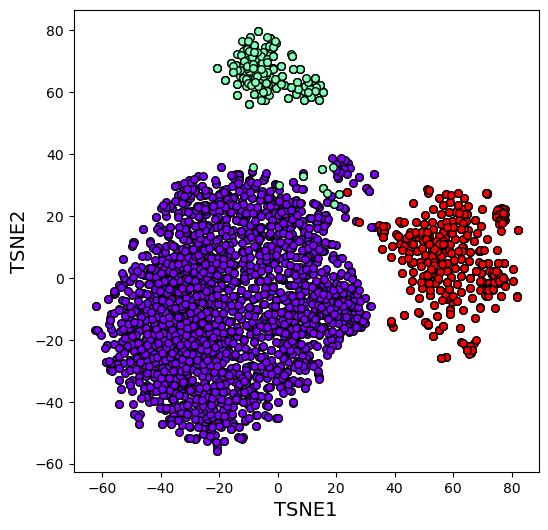

```python
plot_groups(tsne_props,groups,colors = get_colors(3), labels = ['TSNE1','TSNE2'])
plt.show()
```

**QUESTION**  
You should see something that looks strange to you when we plot the cluster membership on the tSNE plot. Why might this be occuring? What could it indicate about the original sequences in the data?

## 3. Building a classifier

Now we will use the clustering information as a target to build a classifier for new sequences.

### knn

Let's try both a kNN classifier and a Random Forest.

```python
# Grid search for KNN; Question: what did we do before?

from sklearn.model_selection import KFold, GridSearchCV
from sklearn.neighbors import KNeighborsClassifier as KNN

param_grid = dict(n_neighbors = list(range(2,10)), weights = ['distance','uniform'])
cv = KFold(n_splits = 5,random_state = 146, shuffle = True)
grid = GridSearchCV(KNN(), param_grid = param_grid, cv = cv, scoring='accuracy')
```

```python
grid.fit(X,groups)
```

```python
# extract specific columns
results = pd.DataFrame(grid.cv_results_)[['params','mean_test_score','rank_test_score']]
```

```python
results
```

[output not shown]

```python
knn = KNN(n_neighbors = 2, weights = 'distance')
knn.fit(X,groups)
```

```python
knn.score(X,groups) #returns the mean accuracy
```

```python
# Use the fitted KNN to predict on new data

test_data = pd.read_csv('data/DNA_test.csv')
test_data.head()
```

```python
# Q: why these steps?
knn_test_groups = knn.predict(pca.transform(SS().fit_transform(test_data.values))[:,:18])

knn_test_groups
```

```python
fig,ax = plot_groups(X[:,:2],groups,colors = get_colors(3), alpha = 0.25)
plot_groups(pca.transform(SS().fit_transform(test_data.values))[:,:2], knn_test_groups, colors = get_colors(3),
            s = 100, ec = 'k', ax = ax, alpha = 1, labels = ['PC1','PC2'])

plt.show()
```

[output not shown]

### RFC

```python
# Grid search for RFC

from sklearn.ensemble import RandomForestClassifier as RFC
param_grid = dict(max_depth = [4, 6, 8], min_samples_split = [5, 10, 15])
cv = KFold(n_splits = 5,random_state = 146, shuffle = True)
grid = GridSearchCV(RFC(random_state = 146), param_grid = param_grid, cv = cv, scoring='accuracy')
```

```python
grid.fit(X, groups)
```

```python
results = pd.DataFrame(grid.cv_results_)[['param_max_depth','param_min_samples_split','mean_test_score','rank_test_score']]
```

```python
# Get the best results
results[results['rank_test_score'] == 1]
#results
```

[output not shown]

```python
rfc = RFC(random_state = 146, n_estimators = 100, max_depth = 8, min_samples_split = 15)
```

```python
rfc.fit(X, groups)
```

```python
rfc_test_groups = rfc.predict(pca.transform(SS().fit_transform(test_data.values))[:,:18])
```

```python
rfc_test_groups
```

```python
fig,ax = plot_groups(X[:,:2],groups,colors = get_colors(3), alpha = 0.25)
plot_groups(pca.transform(SS().fit_transform(test_data.values))[:,:2], rfc_test_groups, colors = get_colors(3),
            s = 100, ec = 'k', ax = ax, alpha = 1, labels = ['PC1','PC2'])
plt.show()
```

[output not shown]

```python
# What doest this mean?

conf_matrix, accuracy = compare_classes(knn_test_groups, rfc_test_groups)
conf_matrix
```

[output not shown]

```python
help(compare_classes)
```

### Behind the curtain

```python
#This is the actual full data set
#Let's cluster it and then compare with known classes
```

```python
full_data = pd.read_csv('data/DNA_full_data.csv')
full_data.head()
```

```python
pca_Full = pca.fit_transform(SS().fit_transform(full_data.values))
```

```python
plt.scatter(pca_Full[:,0], pca_Full[:,1])
```

Let's go ahead and use 3 clusters.

```python
km = KMeans(n_clusters = 3, random_state = 146, n_init=10)
```

```python
km.fit(full_data.values)
```

```python
full_predictions = km.predict(full_data.values)
```

```python
full_predictions
```

```python
#Let's just look at the data labels
labels = pd.read_csv('data/DNA_labels.csv', index_col = 0)
labels
```

```python
conf_matrix, accuracy = compare_classes(labels['Sequence_ID'].values, full_predictions)
conf_matrix
```

```python
labels['Sequence_ID'].values
```

```python
#This tells us which sequences should actually go together
mapping = {0:'Halo', 1:'Helico', 2:'Taq'}
new_full = pd.Series(full_predictions).apply(lambda x: mapping[x] ).values
new_full
```

```python
conf_matrix, accuracy = compare_classes(labels['Sequence_ID'].values, new_full)
conf_matrix
```